# Analysis of IMDB Movie Ratings, with Emphasis on User Predictions and Recommendations

### By: Reed Shay and Advisor Dr. Ying-Ju Chen

[figure not shown]

# Table of Contents

- Import & Merge Data
- Clean Data for Analysis
- Exploratory Data Analysis (EDA)
- Popularity Recommendation System
- Content-Based Recommendation System
- User-Based Collaborative Filtering Recommendation
- Neural Network Model
- Conclusion & Questions

# Import & Merge Data

1. Movies_metadata.csv
   - Main movies file, including predictors such as:
   - budget, revenue, release data, language, production company, genre, overview, country, vote count, etc.
2. keywords.csv
   - Short phrase attached to a title, purposed to describe
3. credits.csv
   - Cast & crew information, including directors and actors
4. ratings_small.csv
   - 100,000 ratings per 700 users

```python
# Merging movies_metadat with credits & keywords ON 'ID'

import pandas as pd
import ast
import json
import numpy as np
import matplotlib.pyplot as plt



def load_data(file_path):
    #Reading the CSV file into a DataFrame
    #Convert the 'release_date' column to datetime.date type
    # Evaluating each element in the columns that have json data and replacing any null values with np.nan and evaluating any non-null values as a Python literal expression and returning the resulting value.
    # Returning the final modified DataFrame
    df = pd.read_csv(file_path, dtype='unicode')
    df['release_date'] = pd.to_datetime(df['release_date'], errors='coerce').apply(lambda x: x.date())

    json_columns = ['belongs_to_collection', 'genres', 'production_companies', 'production_countries', 'spoken_languages']
    for column in json_columns:
        # use ast because json data has single quotes in the csv, which is invalid for a json object;
        df[column] = df[column].apply(lambda x: np.nan if pd.isnull(x) else ast.literal_eval(x))
    return df


# load data
movies_meta = load_data(r"C:\Users\reeds\PycharmProjects\Capstone\Data Set\movies_metadata.csv")
credits_df = pd.read_csv(r"C:\Users\reeds\PycharmProjects\Capstone\Data Set\credits.csv")
keywords_df = pd.read_csv(r"C:\Users\reeds\PycharmProjects\Capstone\Data Set\keywords.csv")

# Make sure id column is the same data type in credits_df & movies_meta
movies_meta['id'] = pd.to_numeric(movies_meta['id'], errors='coerce')
credits_df['id'] = pd.to_numeric(credits_df['id'], errors='coerce')
keywords_df['id'] = pd.to_numeric(keywords_df['id'], errors='coerce')
# Merge on 'id'
movies_meta = movies_meta.merge(credits_df, on = 'id')
movies_meta = movies_meta.merge(keywords_df, on = 'id')
```

# Clean Data for Analysis

- Checking and correcting data types (i.e. release_data to usable metric)
- JSON column manipulation (dictionary --> list)
- Drop Columns not used in analysis (poster_path, adult, etc.)
- NA and empty Entry Analysis
- Budget & Revenue

# Changing Datatypes

```python
# Checking and correcting data types
# change budget, Revenue, id, popularity, Vote_average, Vote_Count to numeric
movies_meta['budget'] = pd.to_numeric(movies_meta['budget'], errors='coerce')
movies_meta['revenue'] = pd.to_numeric(movies_meta['revenue'], errors='coerce')
movies_meta["id"] = pd.to_numeric(movies_meta['id'], errors='coerce', downcast="integer")
movies_meta["popularity"] = pd.to_numeric(movies_meta['popularity'], errors='coerce')
movies_meta['release_date'] = pd.to_datetime(movies_meta['release_date'], errors='coerce')
movies_meta['vote_average'] = pd.to_numeric(movies_meta['vote_average'], errors='coerce')
movies_meta['vote_count'] = pd.to_numeric(movies_meta['vote_count'], errors='coerce')
movies_meta['runtime'] = pd.to_numeric(movies_meta['runtime'], errors = 'coerce')
```

# Handling JSON Variables

```python
# JSON variables : Genres, Belongs_to_collection, Production companies & countries and spoken languages
# Genres, Belongs_to_collection, Prod Companies, Prod Countries and Spoken Languages
def extract_names(x):
    # Check if the input is a list
    if isinstance(x, list):
        # If it's a list, extract the name value from each dictionary in the list
        return [d['name'] for d in x]
    # Check if the input is a dictionary
    elif isinstance(x, dict):
        # If it's a dictionary, return the name value from the dictionary
        return [x['name']]
    # If the input is neither a list nor a dictionary, return an empty list
    else:
        return []

cols = ['genres', 'belongs_to_collection', 'production_companies', 'production_countries', 'spoken_languages']

for col in cols:
    movies_meta[col] = movies_meta[col].apply(lambda x: extract_names(x))


# Cast Names
def extract_cast_names(cast_data):
    cast_names = []
    for i, cast_member in enumerate(cast_data):
        if i < 10:
            cast_names.append(cast_member['name'])
        else:
            break
    return cast_names
# Ensure the 'cast' column has list data
movies_meta['cast'] = movies_meta['cast'].apply(lambda x: [] if pd.isnull(x) else ast.literal_eval(x))

# Extract cast names from the 'cast' column
movies_meta['cast_names'] = movies_meta['cast'].apply(extract_cast_names)
```

# JSON columns cont.

```python
# Director Names
def extract_director_name(crew_data):
    for crew_member in crew_data:
        if crew_member['job'] == 'Director':
            return crew_member['name']
    return np.nan

# Ensure the 'crew' column has list data
movies_meta['crew'] = movies_meta['crew'].apply(lambda x: [] if pd.isnull(x) else ast.literal_eval(x))

# Extract director names from the 'crew' column
movies_meta['director'] = movies_meta['crew'].apply(extract_director_name)



# Keywords
# Ensure the 'keywords' column has list data
movies_meta['keywords'] = movies_meta['keywords'].apply(lambda x: [] if pd.isnull(x) else ast.literal_eval(x))
# Extract keywords from the 'keywords' column
def extract_keywords(keywords_data):
    keywords = []
    for i, keyword in enumerate(keywords_data):
        if i < 10:  # Limit to the first five keywords
            keywords.append(keyword['name'])
        else:
            break
    return keywords

movies_meta['keywords_list'] = movies_meta['keywords'].apply(extract_keywords)
```

# Dropping Columns

```python
# drop columns from drop_df
drop_df = ['homepage', 'poster_path', 'video', 'tagline', 'imdb_id', 'original_title',
           'cast','crew', 'keywords', 'adult']  # keywords_list is the variable we want
for col in drop_df:
    if col in movies_meta.columns:
        movies_meta = movies_meta.drop(col, axis=1)
```

# Analyze NA and Zero Values

```python
# Let's look at the total number of missing values for each predictor
missing_values = movies_meta.isna().sum()
print(missing_values)

empty_genres = movies_meta['genres'].apply(lambda x: len(x) == 0).sum()
print(f"Number of empty genres: {empty_genres}")


zero_budget = movies_meta['budget'].apply(lambda x: x == 0).sum()
zero_revenue = movies_meta['revenue'].apply(lambda x: x == 0).sum()

print(f"Number of zero budget entries: {zero_budget}")
print(f"Number of zero revenue entries: {zero_revenue}")
```

```
belongs_to_collection      0
budget                     0
genres                     0
id                         0
original_language         11
overview                 995
popularity                 0
production_companies       0
production_countries       0
release_date              84
revenue                    0
runtime                  264
spoken_languages           0
status                    82
title                      0
vote_average               0
vote_count                 0
cast_names                 0
director                 917
keywords_list              0
dtype: int64
Number of empty genres: 2524
Number of zero budget entries: 37571
Number of zero revenue entries: 39087
```

# Cleaned Dataset After

- Formatting JSON columns
- Dropping columns
- NA and empty Entry Analysis

```python
display(movies_meta.head(5))
```

|  | belongs_to_collection | budget | genres | id | original_language | overview | popularity | production_companies | production_countries | release_date | revenue | runtime | spoken_languages | status | title | vote_average | vote_count | cast_names | director | keywords_list |
| --- | --- | --- | --- | --- | --- | --- | --- | --- | --- | --- | --- | --- | --- | --- | --- | --- | --- | --- | --- | --- |
| 0 | [] | 160000000 | [Action, Thriller, Science Fiction, Mystery, A... | 27205 | en | Cobb, a skilled thief who commits corporate es... | 29.108149 | [Legendary Pictures, Warner Bros., Syncopy] | [United Kingdom, United States of America] | 2010-07-14 | 825532764 | 148.0 | [English] | Released | Inception | 8.1 | 14075 | [Leonardo DiCaprio, Joseph Gordon-Levitt, Elle... | Christopher Nolan | [loss of lover, dream, kidnapping, sleep, subc... |
| 1 | [The Dark Knight Collection] | 185000000 | [Drama, Action, Crime, Thriller] | 155 | en | Batman raises the stakes in his war on crime. ... | 123.167259 | [DC Comics, Legendary Pictures, Warner Bros., ... | [United Kingdom, United States of America] | 2008-07-16 | 1004558444 | 152.0 | [English, 普通话] | Released | The Dark Knight | 8.3 | 12269 | [Christian Bale, Michael Caine, Heath Ledger, ... | Christopher Nolan | [dc comics, crime fighter, secret identity, sc... |
| 2 | [Avatar Collection] | 237000000 | [Action, Adventure, Fantasy, Science Fiction] | 19995 | en | In the 22nd century, a paraplegic Marine is di... | 185.070892 | [Ingenious Film Partners, Twentieth Century Fo... | [United States of America, United Kingdom] | 2009-12-10 | 2787965087 | 162.0 | [English, Español] | Released | Avatar | 7.2 | 12114 | [Sam Worthington, Zoe Saldana, Sigourney Weave... | James Cameron | [culture clash, future, space war, space colon... |
| 3 | [The Avengers Collection] | 220000000 | [Science Fiction, Action, Adventure] | 24428 | en | When an unexpected enemy emerges and threatens... | 89.887648 | [Paramount Pictures, Marvel Studios] | [United States of America] | 2012-04-25 | 1519557910 | 143.0 | [English] | Released | The Avengers | 7.4 | 12000 | [Robert Downey Jr., Chris Evans, Mark Ruffalo,... | Joss Whedon | [new york, shield, marvel comic, superhero, ba... |
| 4 | [Deadpool Collection] | 58000000 | [Action, Adventure, Comedy] | 293660 | en | Deadpool tells the origin story of former Spec... | 187.860492 | [Twentieth Century Fox Film Corporation, Marve... | [United States of America] | 2016-02-09 | 783112979 | 108.0 | [English] | Released | Deadpool | 7.4 | 11444 | [Ryan Reynolds, Morena Baccarin, Ed Skrein, T.... | Tim Miller | [anti hero, mercenary, marvel comic, superhero... |

# Exploratory Data Analysis (EDA)

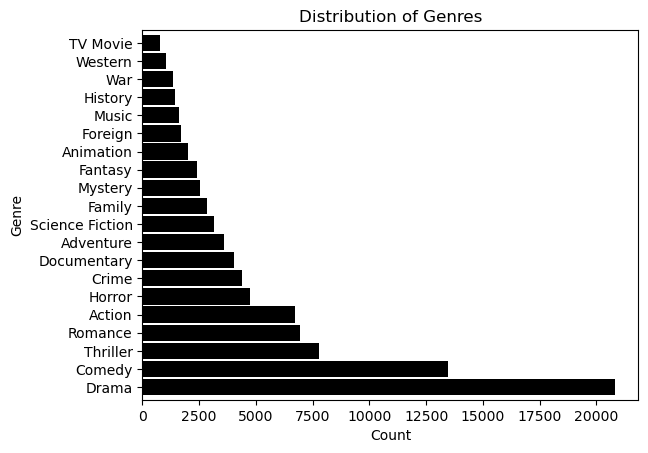

```python
fig
```

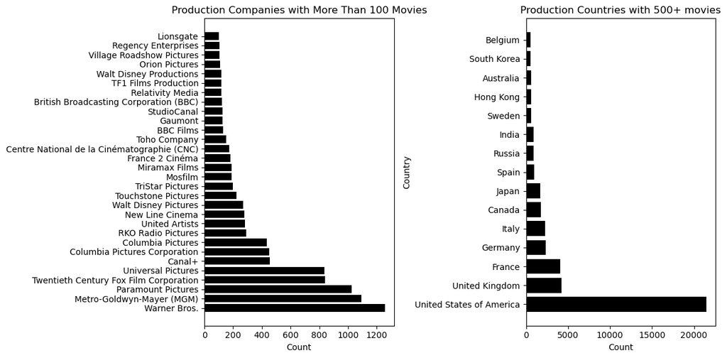

```python
fig
```

# Recommendation Systems

1. Popularity Based Recommendation
2. Content-Based Filtering
3. Collaborative Filtering

## Popularity Based Recommendation

- IMDB ratings use something known as Weighted Ratings. IMDb's rating system is based on a weighted average of the ratings given by users and is the following equation: $ W_R = \frac{v}{v+m}R + \frac{m}{v+m}C$
  - Where v is the number of votes
  - m is the minimum number of votes to be listed (we will use a 95 percentile cutoff)
  - R is the average rating of the particular movie
  - C is the mean vote across the whole dataset
- Let's use this metric to build a simple recommendation system

# Original Dataframe, Ordered by Weighted rating

```python
# Print the updated dataframe
movies_meta[['weighted_rating', 'title', 'director']].head(13)
```

|  | weighted_rating | title | director |
| --- | --- | --- | --- |
| 19 | 8.360240 | The Shawshank Redemption | Frank Darabont |
| 61 | 8.309658 | The Godfather | Francis Ford Coppola |
| 1 | 8.209996 | The Dark Knight | Christopher Nolan |
| 8 | 8.186913 | Fight Club | David Fincher |
| 17 | 8.174380 | Pulp Fiction | Quentin Tarantino |
| 21 | 8.071673 | Forrest Gump | Robert Zemeckis |
| 150 | 8.064963 | Schindler's List | Steven Spielberg |
| 153 | 8.062025 | Whiplash | Damien Chazelle |
| 181 | 8.039924 | Spirited Away | Hayao Miyazaki |
| 63 | 8.028738 | The Empire Strikes Back | Irvin Kershner |
| 0 | 8.027068 | Inception | Christopher Nolan |
| 209 | 8.019146 | Life Is Beautiful | Roberto Benigni |
| 88 | 8.011480 | The Intouchables | Eric Toledano |

# Applications

- We can use this to recommend based off of genre, director, production company, etc.

```python
top_comedy_movies[['weighted_rating', 'title', 'director']]
```

|  | weighted_rating | title | director |
| --- | --- | --- | --- |
| 21 | 8.071673 | Forrest Gump | Robert Zemeckis |
| 209 | 8.019146 | Life Is Beautiful | Roberto Benigni |
| 88 | 8.011480 | The Intouchables | Eric Toledano |
| 53 | 7.847687 | Back to the Future | Robert Zemeckis |
| 129 | 7.799760 | The Grand Budapest Hotel | Wes Anderson |
| 38 | 7.764797 | The Wolf of Wall Street | Martin Scorsese |
| 39 | 7.764212 | Inside Out | Pete Docter |
| 1646 | 7.734884 | Dilwale Dulhania Le Jayenge | Aditya Chopra |
| 122 | 7.711893 | La La Land | Damien Chazelle |
| 34 | 7.675550 | Up | Pete Docter |

# Based off Director, Wes Anderson

```python
ranked_anderson_movies[['title', 'weighted_rating']]
```

|  | title | weighted_rating |
| --- | --- | --- |
| 129 | The Grand Budapest Hotel | 7.799760 |
| 626 | Moonrise Kingdom | 7.202533 |
| 939 | Fantastic Mr. Fox | 7.007961 |
| 859 | The Royal Tenenbaums | 6.963711 |
| 1582 | Rushmore | 6.778962 |
| 1288 | The Darjeeling Limited | 6.613823 |
| 1423 | The Life Aquatic with Steve Zissou | 6.575526 |
| 3959 | Hotel Chevalier | 6.094411 |
| 3167 | Bottle Rocket | 6.088710 |
| 10464 | Come Together | 5.786662 |

# Content Based Filtering

- Broad idea: using a text-based approach, recommend movies based on similar movie features.
- Create a new variable, combined features = [genres, cast_names, director, keywords, overview, etc.]
- Vectorize, text (TF-IDF)--> numerical data
- Calculate similarity, namely using the cosine similarity metric.

### Cosine Similarity

- Idea: to measure the similarity between two vectors in a high-dimensional space by calculating the cosine of the angle between two vectors, projected in a multidimension space.
- cosine similarity(u, v) = $\frac{u \cdot v}{\lVert u \rVert \lVert v \rVert}$, where $u$ and $v$ are the two vectors being compared.

[figure not shown]

# Top 10 Recommendations for Toy Story

```python
movie_title = "Toy Story"
recommendations = content_based_recommendations(movie_title, tfidf_matrix)
print(f"Top 10 recommendations for '{movie_title}':")
recommendations
```

|  | title | similarity_score |
| --- | --- | --- |
| 0 | Toy Story 2 | 0.511418 |
| 1 | Toy Story 3 | 0.459096 |
| 2 | Toy Story That Time Forgot | 0.292212 |
| 3 | Toy Story of Terror! | 0.272110 |
| 4 | Small Fry | 0.264771 |
| 5 | Hawaiian Vacation | 0.248074 |
| 6 | Toy Reanimator | 0.217118 |
| 7 | Small Soldiers | 0.211142 |
| 8 | Partysaurus Rex | 0.207263 |
| 9 | Silent Night, Deadly Night 5: The Toy Maker | 0.205390 |

# Problems/Improvements

- Weighting (repetition)
- Additional/Removal of features
- Lack of a direct error metric
- Varying similarity metric (euclidean distance, Pearson's r, manhattan distance etc.)

# User-based Collaborative Filtering for Movie Recommendations

- Broad idea: recommending items based on user preferences and ratings, based off of similarity to other users.
- Switching datasets → ratings.csv
- Individual user account information, including ratings and movieID

# Recommendations for User 2

```python
display(top_10_recommended_movies)
```

|  | title |
| --- | --- |
| 0 | A Nightmare on Elm Street |
| 1 | Romeo + Juliet |
| 2 | 48 Hrs. |
| 3 | Once Were Warriors |
| 4 | Sissi |
| 5 | Terminator 3: Rise of the Machines |
| 6 | Monsoon Wedding |

# Problems/further progression

- Metric of error (is cross validation appropriate here?)
- Different Similarity Measures
- Cold Start
- Popularity concerns
- Dataset Switch

# Matrix Factorization with Neural Networks

- Collaborative filtering method - used to discover latent features.
- Neural Network framework:
- Input layers for user and movie IDs
- Embedding layers for latent factors
- Flatten layers to prepare for dot product
- Dot product layer to capture interactions between user and movie latent factors
- Output prediction ratings
- Evaluate Mean Squared Error

```python
user_id = 1
recommended_movies = recommend_movies_for_user(user_id, predicted_ratings_df, ratings)
recommended_movies
```

|  | userId | movieId | predicted_rating | title |
| --- | --- | --- | --- | --- |
| 0 | 1 | 3030 | 3.557553 | End of the World |
| 1 | 1 | 73290 | 3.488766 | Urban Explorer |
| 2 | 1 | 759 | 3.449224 | Gentlemen Prefer Blondes |
| 3 | 1 | 55069 | 3.446386 | The Delivery |
| 4 | 1 | 51277 | 3.420188 | Now and Forever |
| 5 | 1 | 116 | 3.417106 | Match Point |
| 6 | 1 | 50641 | 3.403370 | The End of Poverty? |
| 7 | 1 | 309 | 3.396181 | The Celebration |
| 8 | 1 | 1649 | 3.391616 | Bill & Ted's Bogus Journey |
| 9 | 1 | 149 | 3.378770 | Akira |

# Problems

- Overfitting (early stopping-employed)
- Less interpretable latent features
- Computationally expensive
- Hyperparameter tuning (latent dimensions, batch size, epochs, learning rate, etc.)

# Further Work

- Hybrid filtering (including important predictors in NN method)
- Interactive (API keys, letterbox profiles)
- Feature selection in models (scaling)
- How might these recommendation systems be used for new members?

# Personal Problems Faced

- Python/Jupyter
- Dataset (NA, cleaning, missing ID's)
- Subjective results

# Questions?

# About Me: Reed Shay

- Current Senior at the University of Dayton studying Mathematics and Psychology
- My current career interests include Data Science and Data Analytics
- Post-graduation I will be taking a gap year to live in Whistler, Canada with plans to continue my education after the ski season! Either continuing on with a masters in data analytics or joining the work force, time will tell!
- I am more than willing to answer any questions or provide source code, feel free to reach out at $reedshay00@gmail.com$.